# Stats 506, F20, Final Project

Zhilin He, zhilinhe@umich.edu

December 07, 2020

# Link to GitHub repository

https://github.com/zhilinheobv/506-Final-Project

# Introduction

Fuel oil (including kerosene and diesel) is a common source of energy. Although it is not as environmental friendly as natural gas, it is used for heating in many homes and buildings, and other industries like fueling for trucks and ships. Some industries aim to reduce the use of polluting fuel oil since it might cause air pollution and harm people’s health<sup>[1]</sup>. Therefore, proper usage of fuel oil is an interesting topic to consider.

Many buildings use fuel oil as an energy source for various reasons. It’s possible that buildings’ ownership affects the choice of energy sources. In this project, we are trying to find out whether government-owned commercial buildings use more fuel oil than not government-owned buildings, and what fuel oil is used for in different buildings.

# Data

This project uses the 2012 CBECS data. It contains 1119 variables and 6720 sampled observations. The data contains all aspects of information concerning energy consumption about commercial buildings all across the US.

| Variable Name | Variable Description |
| --- | --- |
| PUBID (id) | Building ID |
| REGION | Census region |
| CENDIV (div) | Census division |
| GOVOWN (gov) | Government owned (1) or not (2) |
| FKUSED | Uses fuel oil/diesel/kerosene (1) or not (2) |
| FKTYPE | Fuel oil, diesel or kerosene used |
| FKHTBTU | Fuel oil^ used for heating (thousand BTU) |
| FKCLBTU | Fuel oil used for cooling (thousand BTU) |
| FKWTBTU | Fuel oil used for water heating (thousand BTU) |
| FKCKBTU | Fuel oil used for cooking (thousand BTU) |
| FKOTBTU | Fuel oil used for other reasons (thousand BTU) |
| FKBTU | Annual fuel oil consumption (thousand BTU) |
| FKEXP | Annual fuel oil expenditure ($) |
| FINALWT | Full sample building weight |
| FINALWT1-197 | Final replicate weights |

^ Including diesel and kerosene. Same with “Fuel oil” below.

**Table 1**. Variable descriptions

# Methods

We use the jackknife method to estimate standard error. This method uses replicate weights to repeatedly estimate the statistics of interest and calculate the differences between these estimates and the full-sample estimate<sup>[2]</sup>.

We also use Pearson’s chi-squared test to verify whether the effect of building ownership is significant for fuel oil usage.

# Analysis

## Data Cleaning

Firstly, we take a look at the data. Data summary is shown below.

| id | div | gov | fo_used | fo_type | heating |
| --- | --- | --- | --- | --- | --- |
| Min. : 1 | South Atlantic :1348 | Goverment :1337 | TRUE :1515 | Fuel oil : 353 | Min. : 0 |
| 1st Qu.:1681 | Pacific :1113 | Non-goverment:5383 | FALSE:5205 | Diesel : 782 | 1st Qu.: 0 |
| Median :3360 | East North Central: 900 |  |  | Kerosene : 23 | Median : 0 |
| Mean :3360 | West South Central: 852 |  |  | More than one: 79 | Mean : 394569 |
| 3rd Qu.:5040 | Middle Atlantic : 787 |  |  | Unknown : 278 | 3rd Qu.: 0 |
| Max. :6720 | West North Central: 559 |  |  | NA’s :5205 | Max. :75555274 |
|  | (Other) :1161 |  |  |  | NA’s :5205 |

| cooling | waterheating | cooking | other | total | expenditure |
| --- | --- | --- | --- | --- | --- |
| Min. : 0 | Min. : 0 | Min. : 0 | Min. : 0 | Min. : 0 | Min. : 0 |
| 1st Qu.: 0 | 1st Qu.: 0 | 1st Qu.: 0 | 1st Qu.: 6805 | 1st Qu.: 33750 | 1st Qu.: 954 |
| Median : 0 | Median : 0 | Median : 0 | Median : 124553 | Median : 208826 | Median : 5374 |
| Mean : 17896 | Mean : 5680 | Mean : 35505 | Mean : 702369 | Mean : 1156019 | Mean : 27926 |
| 3rd Qu.: 0 | 3rd Qu.: 0 | 3rd Qu.: 0 | 3rd Qu.: 663206 | 3rd Qu.: 810147 | 3rd Qu.: 20295 |
| Max. :10094242 | Max. :796586 | Max. :30923934 | Max. :34166771 | Max. :96306196 | Max. :2041370 |
| NA’s :5205 | NA’s :5205 | NA’s :5205 | NA’s :5205 | NA’s :5205 | NA’s :5205 |

**Table 2**. Summary of variables

## Fuel oil usage

We calculate the weighted frequency of fuel oil usage using the survey weights.

| ownership | division | fuel oil used | fuel oil not used | percent used | LB used | UB used | LB not used | UB not used |
| --- | --- | --- | --- | --- | --- | --- | --- | --- |
| Goverment | New England | 14031.772 | 21928.31 | 0.3902041 | 12590.067 | 15473.477 | 24769.05 | 24769.05 |
| Non-goverment | New England | 100775.757 | 164899.36 | 0.3793195 | 89899.975 | 111651.539 | 172990.39 | 172990.39 |
| Goverment | Middle Atlantic | 18537.168 | 28303.00 | 0.3957537 | 17703.126 | 19371.211 | 30015.30 | 30015.30 |
| Non-goverment | Middle Atlantic | 83336.272 | 373671.66 | 0.1823519 | 77888.460 | 88784.083 | 380390.50 | 380390.50 |
| Goverment | East North Central | 17556.040 | 82169.55 | 0.1760435 | 14774.439 | 20337.641 | 85246.93 | 85246.93 |
| Non-goverment | East North Central | 28168.832 | 607353.11 | 0.0443239 | 27260.189 | 29077.474 | 629190.11 | 629190.11 |
| Goverment | West North Central | 10038.200 | 61702.01 | 0.1399243 | 8978.305 | 11098.094 | 65486.18 | 65486.18 |
| Non-goverment | West North Central | 21209.468 | 409282.07 | 0.0492680 | 19320.069 | 23098.868 | 424291.46 | 424291.46 |
| Goverment | South Atlantic | 15893.248 | 104762.85 | 0.1317235 | 14989.815 | 16796.680 | 109414.07 | 109414.07 |
| Non-goverment | South Atlantic | 53159.350 | 917568.99 | 0.0547623 | 50804.875 | 55513.825 | 944142.43 | 944142.43 |
| Goverment | East South Central | 7662.804 | 59381.11 | 0.1142953 | 7251.888 | 8073.721 | 61805.53 | 61805.53 |
| Non-goverment | East South Central | 21865.835 | 280725.32 | 0.0722620 | 18951.291 | 24780.380 | 288827.50 | 288827.50 |
| Goverment | West South Central | 6747.545 | 94104.24 | 0.0669056 | 5938.566 | 7556.524 | 99874.19 | 99874.19 |
| Non-goverment | West South Central | 25175.664 | 659756.56 | 0.0367564 | 22622.834 | 27728.495 | 691389.04 | 691389.04 |
| Goverment | Mountain | 1919.560 | 58784.86 | 0.0316214 | 1746.692 | 2092.429 | 64024.19 | 64024.19 |
| Non-goverment | Mountain | 6128.668 | 271611.53 | 0.0220662 | 4950.844 | 7306.491 | 280270.61 | 280270.61 |
| Goverment | Pacific | 9037.605 | 163462.19 | 0.0523920 | 8135.849 | 9939.361 | 172364.19 | 172364.19 |
| Non-goverment | Pacific | 25491.730 | 730936.21 | 0.0337001 | 23924.355 | 27059.105 | 778860.52 | 778860.52 |

**Table 3**. Frequency table of buildings using oil by census division and ownership

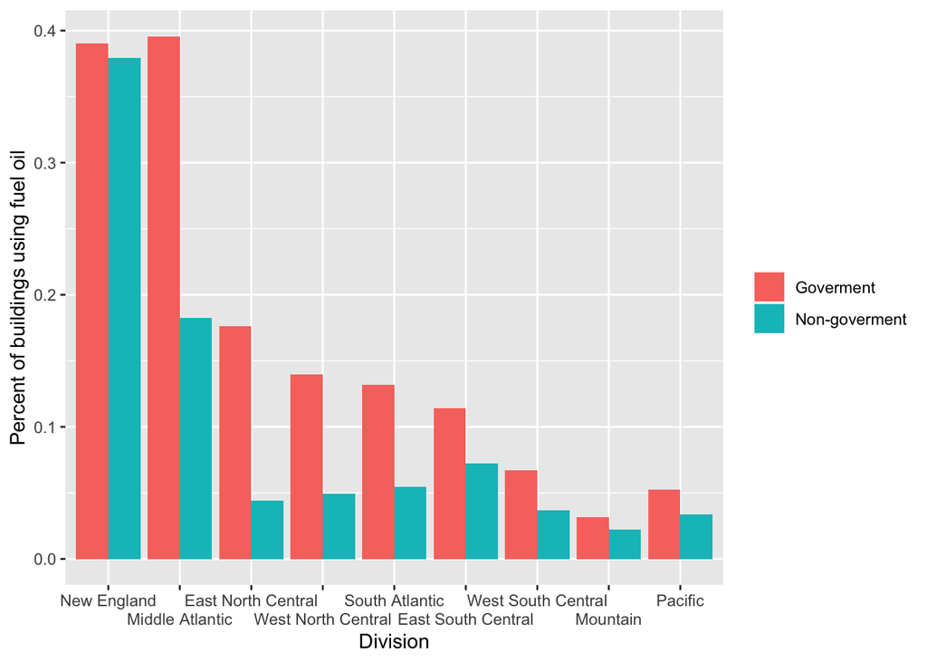

**Figure 1**. Percent of buildings using fuel oil by census division and ownership

From figure 1, we can see that the percentage of government buildings that use fuel oil is greater in all divisions, but the difference is more obvious in Middle Atlantic, East North Central, West North Central and South Atlantic divisions. We can use Pearson chi-squared test to verify whether this difference is statistically significant.

| Division | Chi-squared statistic | p-value |
| --- | --- | --- |
| New England | 15.87111 | p < 0.001 |
| Middle Atlantic | 11993.06659 | p < 0.001 |
| East North Central | 25640.82270 | p < 0.001 |
| West North Central | 8660.15322 | p < 0.001 |
| South Atlantic | 10723.68072 | p < 0.001 |
| East South Central | 1318.65061 | p < 0.001 |
| West South Central | 2049.37892 | p < 0.001 |
| Mountain | 195.51565 | p < 0.001 |
| Pacific | 1370.74663 | p < 0.001 |
| Total | 25577.63825 | p < 0.001 |

**Table 4**. Result of chi-squared tests

It turns out the difference of fuel oil usage between government and non-government buildings is significant for all divisions. This is possibly due to the fact that the full sample size is large enough to identify this difference.

## Consumption

We calculate the annual consumption of fuel oil among the buildings using fuel oil as an energy source. The consumptions for each specific use are also calculated. The graph for consumptions in different divisions is shown below, with estimated error bars:

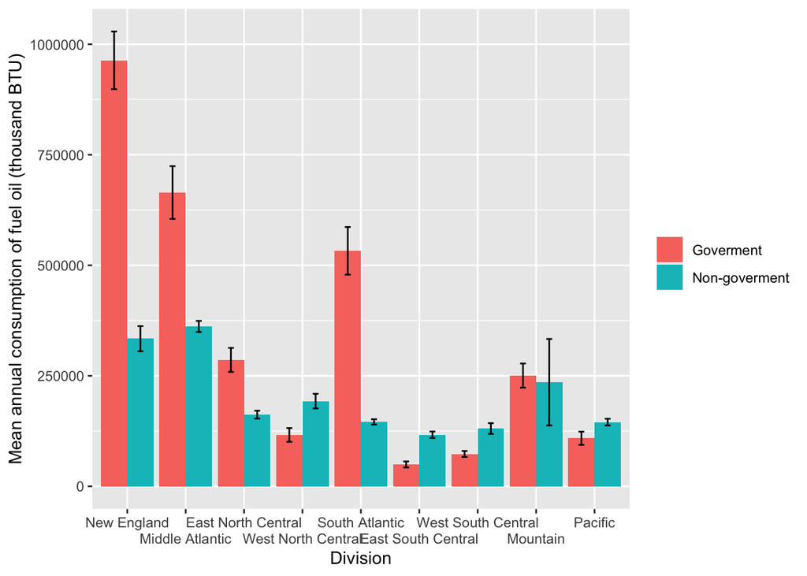

**Figure 2**. Mean annual fuel oil consumption for buildings by division and ownership

| gov | div | mean | se | lower | upper |
| --- | --- | --- | --- | --- | --- |
| Goverment | New England | 963511.69 | 33307.602 | 898229.99 | 1028793.39 |
| Non-goverment | New England | 333986.99 | 14512.312 | 305543.38 | 362430.60 |
| Goverment | Middle Atlantic | 664588.14 | 30426.772 | 604952.77 | 724223.52 |
| Non-goverment | Middle Atlantic | 361643.73 | 6389.122 | 349121.28 | 374166.18 |
| Goverment | East North Central | 285926.28 | 13854.153 | 258772.64 | 313079.92 |
| Non-goverment | East North Central | 162093.98 | 4539.531 | 153196.66 | 170991.29 |
| Goverment | West North Central | 116277.49 | 7922.396 | 100749.88 | 131805.10 |
| Non-goverment | West North Central | 192769.36 | 8448.660 | 176210.29 | 209328.43 |
| Goverment | South Atlantic | 532670.68 | 27502.782 | 478766.22 | 586575.14 |
| Non-goverment | South Atlantic | 145715.53 | 3064.887 | 139708.47 | 151722.60 |
| Goverment | East South Central | 49494.84 | 3491.005 | 42652.59 | 56337.08 |
| Non-goverment | East South Central | 116708.93 | 3711.652 | 109434.23 | 123983.64 |
| Goverment | West South Central | 73193.19 | 3447.682 | 66435.86 | 79950.52 |
| Non-goverment | West South Central | 130696.54 | 6207.395 | 118530.27 | 142862.81 |
| Goverment | Mountain | 250533.29 | 13886.984 | 223315.30 | 277751.28 |
| Non-goverment | Mountain | 235536.52 | 49878.258 | 137776.93 | 333296.11 |
| Goverment | Pacific | 108745.77 | 7627.133 | 93796.87 | 123694.68 |
| Non-goverment | Pacific | 145264.40 | 3842.659 | 137732.93 | 152795.88 |
| Goverment | Total | 422277.35 | 8729.799 | 405167.26 | 439387.45 |
| Non-goverment | Total | 249609.90 | 3144.955 | 243445.90 | 255773.90 |

**Table 5**. Mean annual fuel oil consumption for buildings

In New England, Middle Atlantic, East North Central and South Atlantic divisions, government buildings consume significantly more fuel oil than non-government buildings on average. In Mountain Division, the difference is not significant. In other divisions, non-government buildings consume more fuel oil annually. Overall, because New England and Middle Atlantic divisions consume fuel oil the most in the US, government buildings consume significantly more fuel oil than other buildings annually on average.

## Detailed uses

Fuel oil can be used in many ways in buildings. We consider the differences of uses between goverment buildings and non-government ones.

| gov | div | heating | cooling | waterheating | cooking | other |
| --- | --- | --- | --- | --- | --- | --- |
| Goverment | New England | 831720.04 | 0.0000 | 2832.7359868 | 0.00000 | 128958.91 |
| Non-goverment | New England | 299073.31 | 655.8435 | 1643.9363494 | 1726.87853 | 30887.02 |
| Goverment | Middle Atlantic | 551263.12 | 3611.3185 | 3050.3485278 | 0.00000 | 106663.35 |
| Non-goverment | Middle Atlantic | 254523.22 | 7640.7713 | 2090.4352639 | 5780.20675 | 91609.09 |
| Goverment | East North Central | 205466.86 | 1624.3409 | 14.2704173 | 0.00000 | 78820.81 |
| Non-goverment | East North Central | 81157.64 | 0.0000 | 6.9916443 | 0.00000 | 80929.35 |
| Goverment | West North Central | 53344.88 | 0.0000 | 2732.3831181 | 0.00000 | 60200.23 |
| Non-goverment | West North Central | 125394.44 | 0.0000 | 200.2502431 | 1078.22725 | 66096.44 |
| Goverment | South Atlantic | 241525.58 | 0.0000 | 2037.3908551 | 0.00000 | 289107.70 |
| Non-goverment | South Atlantic | 56405.43 | 1320.2462 | 5599.5459137 | 900.57979 | 81489.73 |
| Goverment | East South Central | 0.00 | 0.0000 | 12.1093298 | 0.00000 | 49482.73 |
| Non-goverment | East South Central | 74217.04 | 0.0000 | 9.8068558 | 0.00000 | 42482.09 |
| Goverment | West South Central | 1032.36 | 0.0000 | 0.0000000 | 0.00000 | 72160.83 |
| Non-goverment | West South Central | 12502.29 | 0.0000 | 18.8719399 | 0.00000 | 118175.37 |
| Goverment | Mountain | 0.00 | 0.0000 | 356.9030921 | 0.00000 | 250176.38 |
| Non-goverment | Mountain | 30745.62 | 271.2235 | 0.1660811 | 0.00000 | 204519.50 |
| Goverment | Pacific | 0.00 | 0.0000 | 818.3570389 | 1108.43920 | 106818.98 |
| Non-goverment | Pacific | 49790.53 | 0.0000 | 201.8280987 | 0.00000 | 95272.05 |
| Goverment | Total | 294581.59 | 941.2039 | 1622.1663039 | 98.76993 | 125033.63 |
| Non-goverment | Total | 171606.24 | 2120.6341 | 1773.3516725 | 1988.63459 | 72121.04 |

**Table 6**. Detailed uses of fuel oil

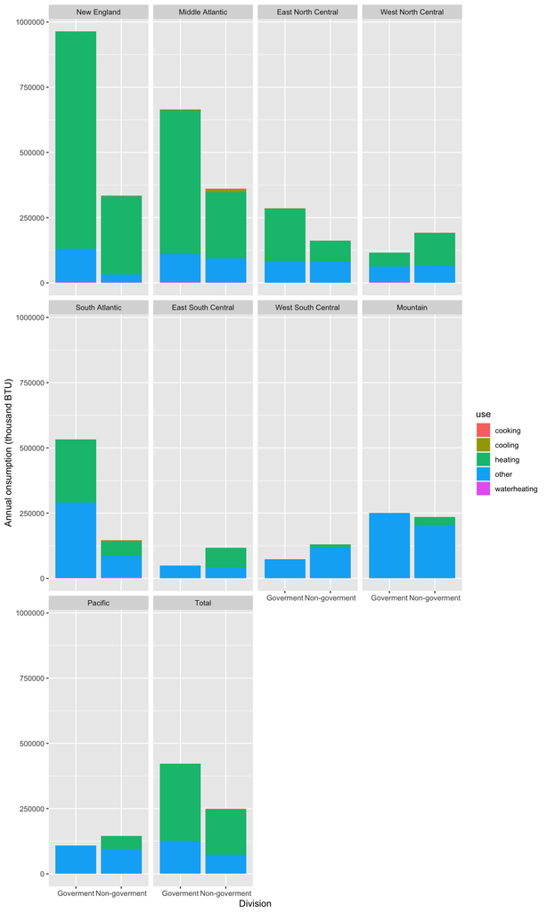

**Figure 3**. Stacked bar plots for different uses of fuel oil

From the figure we can clearly see that uses of fuel oil mainly differs by census divisions, possibly due to climate reasons. The uses of fuel oil in government-owned and not government-owned buildings are not so different if heating is the main use of fuel oil in the division. For East South Central, West South Central, Mountain and Pacific divisions, heating is not the main use of fuel oil. In these divisions, government buildings almost only use fuel oil for other reasons (including manufacturing and electricity generation). But non-government buildings still use some fuel oil for heating.

## Type of fuel oil

In this project, “fuel oil” includes (heavy) fuel oil, kerosene and diesel. We consider the differences of type of fuel oil used in those buildings using fuel oil as an energy source.

| gov | div | fo_typeFuel oil | fo_typeDiesel | fo_typeKerosene | fo_typeMore than one | fo_typeUnknown |
| --- | --- | --- | --- | --- | --- | --- |
| Goverment | New England | 10008.20926 | 1176.0464 | 1387.07659 | 1168.838533 | 291.6010 |
| Non-goverment | New England | 85696.44872 | 6175.2985 | 1387.07659 | 5148.016715 | 2368.9163 |
| Goverment | Middle Atlantic | 11522.55998 | 1095.7556 | 1858.29285 | 457.483121 | 3603.0768 |
| Non-goverment | Middle Atlantic | 39773.34814 | 15690.6690 | 11078.49751 | 3735.513553 | 13058.2436 |
| Goverment | East North Central | 611.59269 | 4911.2823 | 4458.21006 | 317.358516 | 7257.5965 |
| Non-goverment | East North Central | 12852.61609 | 6906.5392 | 178.39373 | 110.150013 | 8121.1326 |
| Goverment | West North Central | 3231.51863 | 3756.5780 | 1484.51505 | 19.690263 | 1545.8978 |
| Non-goverment | West North Central | 10082.69960 | 6438.3027 | 1807.46287 | 1755.892772 | 1125.1101 |
| Goverment | South Atlantic | 1509.23496 | 9933.0040 | 0.00000 | 188.300041 | 4262.7086 |
| Non-goverment | South Atlantic | 22302.43625 | 17449.3251 | 4913.02064 | 129.463685 | 8365.1042 |
| Goverment | East South Central | 0.00000 | 5581.0438 | 0.00000 | 5.982684 | 2075.7780 |
| Non-goverment | East South Central | 6978.71476 | 7145.5759 | 3614.92573 | 1733.152467 | 2393.4661 |
| Goverment | West South Central | 0.00000 | 3321.9424 | 0.00000 | 3.657082 | 3421.9457 |
| Non-goverment | West South Central | 1031.02549 | 12336.1951 | 1807.46287 | 897.685905 | 9103.2951 |
| Goverment | Mountain | 385.44830 | 904.2397 | 0.00000 | 28.619654 | 601.2528 |
| Non-goverment | Mountain | 46.14503 | 5485.0594 | 49.81985 | 0.000000 | 547.6434 |
| Goverment | Pacific | 0.00000 | 4210.3745 | 0.00000 | 0.000000 | 4827.2304 |
| Non-goverment | Pacific | 6309.18418 | 9735.6014 | 880.78346 | 147.401067 | 8418.7598 |
| Goverment | Total | 27268.56382 | 34890.2667 | 9188.09454 | 2189.929894 | 27887.0877 |
| Non-goverment | Total | 185072.61826 | 87362.5664 | 25717.44325 | 13657.276178 | 53501.6711 |

**Table 7**. Types of fuel oil

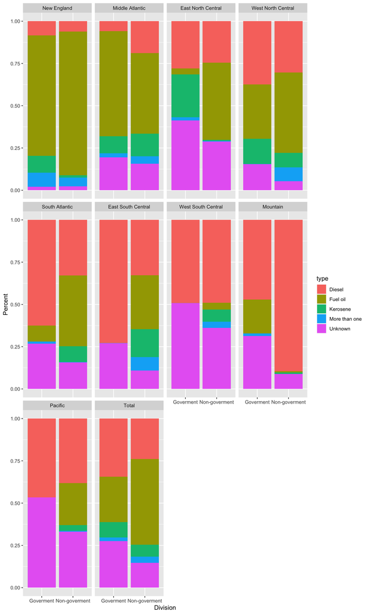

**Figure 4**. Stacked bar plots for type of fuel oil

In general, government buildings use less heavy fuel oil than non-government buildings. However, in Mountain Division, government buildings use significantly more heavy fuel oil. In New England, East and West North Central divisions, government buildings use kerosene more, but in other divisions, the difference is not obvious or non-government buildings use kerosene more. The type of fuel oil that buildings use also differs by census division.

# Conclusion

The analysis about CBECS 2012 data provides some evidence for the assumption that government-owned buildings are more likely to use fuel oil as a source of energy, and they consume more fuel oil. However, generally non-government buildings consume more heavy fuel oil which is more polluting than kerosene and diesel.

Different census divisions use fuel oil for different reasons. In divisions where heating is not the main use of fuel oil, government buildings don’t use fuel oil for heating entirely, while non-government buildings still use it for heating.

# To-do list

1. Finish conclusion.
2. Possibly add analysis by considering the effect of building activity.
3. Possibly add propensity score analysis.

# References

[1] Fuel oil. Wikipedia.

[2] [Jackknife resampling](https://en.wikipedia.org/wiki/Jackknife_resampling). Wikipedia.

[3] [Propensity Score Analysis with Survey Weighted Data](https://www.ncbi.nlm.nih.gov/pmc/articles/PMC5802372/).